# Assumptions of Linear Regression

```python
import matplotlib.pyplot as plt
import numpy as np
import pandas as pd
from sklearn import linear_model
import statsmodels.formula.api as smf
from sqlalchemy import create_engine
from scipy.stats import bartlett
from scipy.stats import levene


# Display preferences.
%matplotlib inline
pd.options.display.float_format = '{:.2f}'.format

import warnings
warnings.filterwarnings(action="ignore")

postgres_user = 'dsbc_student'
postgres_pw = '7*.8G9QH21'
postgres_host = '142.93.121.174'
postgres_port = '5432'
postgres_db = 'weatherinszeged'

engine = create_engine('postgresql://{}:{}@{}:{}/{}'.format(
    postgres_user, postgres_pw, postgres_host, postgres_port, postgres_db))

weather = pd.read_sql_query('select * from weatherinszeged',con=engine)

# no need for an open connection, as we're only doing a single query
engine.dispose()

weather.head(10)
```

|  | date | summary | preciptype | temperature | apparenttemperature | humidity | windspeed | windbearing | visibility | loudcover | pressure | dailysummary |
| --- | --- | --- | --- | --- | --- | --- | --- | --- | --- | --- | --- | --- |
| 0 | 2006-03-31 22:00:00+00:00 | Partly Cloudy | rain | 9.47 | 7.39 | 0.89 | 14.12 | 251.00 | 15.83 | 0.00 | 1015.13 | Partly cloudy throughout the day. |
| 1 | 2006-03-31 23:00:00+00:00 | Partly Cloudy | rain | 9.36 | 7.23 | 0.86 | 14.26 | 259.00 | 15.83 | 0.00 | 1015.63 | Partly cloudy throughout the day. |
| 2 | 2006-04-01 00:00:00+00:00 | Mostly Cloudy | rain | 9.38 | 9.38 | 0.89 | 3.93 | 204.00 | 14.96 | 0.00 | 1015.94 | Partly cloudy throughout the day. |
| 3 | 2006-04-01 01:00:00+00:00 | Partly Cloudy | rain | 8.29 | 5.94 | 0.83 | 14.10 | 269.00 | 15.83 | 0.00 | 1016.41 | Partly cloudy throughout the day. |
| 4 | 2006-04-01 02:00:00+00:00 | Mostly Cloudy | rain | 8.76 | 6.98 | 0.83 | 11.04 | 259.00 | 15.83 | 0.00 | 1016.51 | Partly cloudy throughout the day. |
| 5 | 2006-04-01 03:00:00+00:00 | Partly Cloudy | rain | 9.22 | 7.11 | 0.85 | 13.96 | 258.00 | 14.96 | 0.00 | 1016.66 | Partly cloudy throughout the day. |
| 6 | 2006-04-01 04:00:00+00:00 | Partly Cloudy | rain | 7.73 | 5.52 | 0.95 | 12.36 | 259.00 | 9.98 | 0.00 | 1016.72 | Partly cloudy throughout the day. |
| 7 | 2006-04-01 05:00:00+00:00 | Partly Cloudy | rain | 8.77 | 6.53 | 0.89 | 14.15 | 260.00 | 9.98 | 0.00 | 1016.84 | Partly cloudy throughout the day. |
| 8 | 2006-04-01 06:00:00+00:00 | Partly Cloudy | rain | 10.82 | 10.82 | 0.82 | 11.32 | 259.00 | 9.98 | 0.00 | 1017.37 | Partly cloudy throughout the day. |
| 9 | 2006-04-01 07:00:00+00:00 | Partly Cloudy | rain | 13.77 | 13.77 | 0.72 | 12.53 | 279.00 | 9.98 | 0.00 | 1017.22 | Partly cloudy throughout the day. |

```python
Y=weather.temperature

X=weather[['humidity', 'windspeed', 'windbearing', 'pressure']]

lrm= linear_model.LinearRegression()

lrm.fit(X, Y)

print('Coefficients: \n{}'.format(lrm.coef_))
print('\nIntercept: \n{}'.format(lrm.intercept_))
```

```
Coefficients:
[-3.24962454e+01 -2.01413742e-01  4.04836936e-03 -6.91759209e-04]

Intercept:
37.926438185285306
```

```python
#Check Gauss Markov conditions of model
#Condition 2:Error term should average to 0

predictions= lrm.predict(X)

errors= Y - predictions

print('The mean of the errors in the weather dataset is {}.'.format(np.mean(errors)))
```

```
The mean of the errors in the weather dataset is -7.449232417867907e-16.
```

Condition 2 is met: mean of the errors is ~0.

```python
#Condition 3: Homoscedasticity

bartlett_stats= bartlett(predictions, errors)
levene_stats= levene(predictions, errors)

print('The Bartlett test shows a T-stat of {:3g} and a P-value of {}'.format(bartlett_stats[0], bartlett_stats[1]))
print('The Levene test shows a T-stat of {:3g} and a P-value of {}'.format(levene_stats[0], levene_stats[1]))
```

```
The Bartlett test shows a T-stat of 2464.84 and a P-value of 0.0
The Levene test shows a T-stat of 2321.24 and a P-value of 0.0
```

Test rejects null hypothesis-results are heteroscedastic. Model may overpredict

```python
#Condition 4: Low multicollinearity
weather.corr()[['temperature', 'humidity', 'windbearing', 'windspeed', 'pressure']]
```

|  | temperature | humidity | windbearing | windspeed | pressure |
| --- | --- | --- | --- | --- | --- |
| temperature | 1.00 | -0.63 | 0.03 | 0.01 | -0.01 |
| apparenttemperature | 0.99 | -0.60 | 0.03 | -0.06 | -0.00 |
| humidity | -0.63 | 1.00 | 0.00 | -0.22 | 0.01 |
| windspeed | 0.01 | -0.22 | 0.10 | 1.00 | -0.05 |
| windbearing | 0.03 | 0.00 | 1.00 | 0.10 | -0.01 |
| visibility | 0.39 | -0.37 | 0.05 | 0.10 | 0.06 |
| loudcover | nan | nan | nan | nan | nan |
| pressure | -0.01 | 0.01 | -0.01 | -0.05 | 1.00 |

Low multicollinearity between temperature and independent variables- passes check.

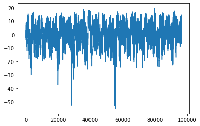

```python
# Condition 5: Error terms should not be correlated with each other.
plt.plot(errors)
plt.show()
```

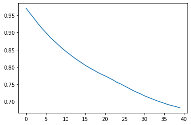

```python
from statsmodels.tsa.stattools import acf

acf_data = acf(errors)

plt.plot(acf_data[1:])
plt.show()
```

Condition 5 not met- strong correlation between error terms.

```python
#Condition 6: Features should not be coordinated with errors.
#Concatenate errors to feature list to form
feat= pd.concat([X, errors], axis=1)
feat.corr()
```

|  | humidity | windspeed | windbearing | pressure | temperature |
| --- | --- | --- | --- | --- | --- |
| humidity | 1.00 | -0.22 | 0.00 | 0.01 | -0.00 |
| windspeed | -0.22 | 1.00 | 0.10 | -0.05 | 0.00 |
| windbearing | 0.00 | 0.10 | 1.00 | -0.01 | -0.00 |
| pressure | 0.01 | -0.05 | -0.01 | 1.00 | -0.00 |
| temperature | -0.00 | 0.00 | -0.00 | -0.00 | 1.00 |

Condition 6 is met- features have no correlation with errors.

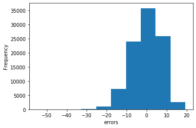

```python
#Test normality of errors
plt.hist(errors)
plt.xlabel('errors')
plt.ylabel('Frequency')
plt.show()
```

```python
from scipy.stats import normaltest
from scipy.stats import jarque_bera

jb_stats = jarque_bera(errors)
norm_stats = normaltest(errors)

print("Jarque-Bera test statistics is {0} and p value is {1}".format(jb_stats[0], jb_stats[1]))
print("Normality test statistics is {0} and p value is {1}".format(norm_stats[0], norm_stats[1]))
```

```
Jarque-Bera test statistics is 3793.2967352523665 and p value is 0.0
Normality test statistics is 3375.432307699586 and p value is 0.0
```

P-values of both tests indicate distribution is not normal.

## Part 2: House prices Model

```python
postgres_user = 'dsbc_student'
postgres_pw = '7*.8G9QH21'
postgres_host = '142.93.121.174'
postgres_port = '5432'
postgres_db = 'houseprices'
```

```python
engine = create_engine('postgresql://{}:{}@{}:{}/{}'.format(
    postgres_user, postgres_pw, postgres_host, postgres_port, postgres_db))
houses = pd.read_sql_query('select * from houseprices',con=engine)

engine.dispose()

houses.head(10)
```

|  | id | mssubclass | mszoning | lotfrontage | lotarea | street | alley | lotshape | landcontour | utilities | ... | poolarea | poolqc | fence | miscfeature | miscval | mosold | yrsold | saletype | salecondition | saleprice |
| --- | --- | --- | --- | --- | --- | --- | --- | --- | --- | --- | --- | --- | --- | --- | --- | --- | --- | --- | --- | --- | --- |
| 0 | 1 | 60 | RL | 65.00 | 8450 | Pave | None | Reg | Lvl | AllPub | ... | 0 | None | None | None | 0 | 2 | 2008 | WD | Normal | 208500 |
| 1 | 2 | 20 | RL | 80.00 | 9600 | Pave | None | Reg | Lvl | AllPub | ... | 0 | None | None | None | 0 | 5 | 2007 | WD | Normal | 181500 |
| 2 | 3 | 60 | RL | 68.00 | 11250 | Pave | None | IR1 | Lvl | AllPub | ... | 0 | None | None | None | 0 | 9 | 2008 | WD | Normal | 223500 |
| 3 | 4 | 70 | RL | 60.00 | 9550 | Pave | None | IR1 | Lvl | AllPub | ... | 0 | None | None | None | 0 | 2 | 2006 | WD | Abnorml | 140000 |
| 4 | 5 | 60 | RL | 84.00 | 14260 | Pave | None | IR1 | Lvl | AllPub | ... | 0 | None | None | None | 0 | 12 | 2008 | WD | Normal | 250000 |
| 5 | 6 | 50 | RL | 85.00 | 14115 | Pave | None | IR1 | Lvl | AllPub | ... | 0 | None | MnPrv | Shed | 700 | 10 | 2009 | WD | Normal | 143000 |
| 6 | 7 | 20 | RL | 75.00 | 10084 | Pave | None | Reg | Lvl | AllPub | ... | 0 | None | None | None | 0 | 8 | 2007 | WD | Normal | 307000 |
| 7 | 8 | 60 | RL | nan | 10382 | Pave | None | IR1 | Lvl | AllPub | ... | 0 | None | None | Shed | 350 | 11 | 2009 | WD | Normal | 200000 |
| 8 | 9 | 50 | RM | 51.00 | 6120 | Pave | None | Reg | Lvl | AllPub | ... | 0 | None | None | None | 0 | 4 | 2008 | WD | Abnorml | 129900 |
| 9 | 10 | 190 | RL | 50.00 | 7420 | Pave | None | Reg | Lvl | AllPub | ... | 0 | None | None | None | 0 | 1 | 2008 | WD | Normal | 118000 |

10 rows × 81 columns

```python
#Cleaned variables
from scipy.stats.mstats import winsorize
houses.garagecars= winsorize(houses.garagecars, (0, 0.05))
houses.grlivarea= winsorize(houses.grlivarea, (0, 0.05))
houses.totalbsmtsf= winsorize(houses.totalbsmtsf, (0, 0.05))
houses.firstflrsf= winsorize(houses.firstflrsf, (0, 0.05))
```

```python
Y=houses.saleprice

X=houses[['overallqual', 'garagecars', 'grlivarea', 'totalbsmtsf', 'firstflrsf']]

lrm= linear_model.LinearRegression()

lrm.fit(X, Y)

print('\nCoefficients: \n', lrm.coef_)
print('\nIntercept: \n', lrm.intercept_)
```

```
Coefficients:
 [2.38677347e+04 1.63578756e+04 4.77245580e+01 3.30429928e+01
 1.71409352e+01]

Intercept:
 -118833.32129406426
```

Condition 1 of OLS: Target variable should be a linear function of the models coefficients.

```python
#Condition 2: Error term should be 0 on average.
predictions2= lrm.predict(X)

errors_houses= Y - predictions2

print('The mean error for houses is {:3g}'.format(np.mean(errors_houses)))
```

```
The mean error for houses is -4.06656e-12
```

Condition 2 met- mean error is approximately 0 since intercept was included.

```python
#Assumption 3: Homoscedasticity
bartlett_stats= bartlett(predictions2, errors_houses)
levene_stats= levene(predictions2, errors_houses)

print('The Bartlett t-stat is {:3g} and the p-value is {:3g}'.format(bartlett_stats[0], bartlett_stats[1]))
print('The Levene t-stat is {:3g} and the p-value is {:3g}'.format(levene_stats[0], levene_stats[1]))
```

```
The Bartlett t-stat is 461.55 and the p-value is 2.21066e-102
The Levene t-stat is 518.188 and the p-value is 1.00583e-105
```

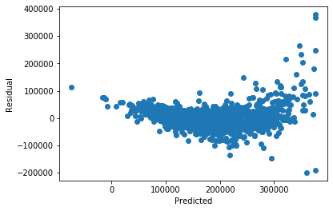

```python
#Heteroscedascity visualized
plt.scatter(predictions2, errors_houses)
plt.xlabel('Predicted')
plt.ylabel('Residual')
```

P-values are < 0.05, Assumption 3 not met. Model's accuracy of prediction will be weak for large values, only as good as average error variance.

```python
#Assumption 4: Low multicollinearity
houses.corr()[['overallqual', 'garagecars', 'grlivarea', 'totalbsmtsf', 'firstflrsf']]
```

|  | overallqual | garagecars | grlivarea | totalbsmtsf | firstflrsf |
| --- | --- | --- | --- | --- | --- |
| id | -0.03 | 0.01 | 0.00 | -0.02 | 0.00 |
| mssubclass | 0.03 | -0.04 | 0.08 | -0.25 | -0.26 |
| lotfrontage | 0.25 | 0.29 | 0.35 | 0.31 | 0.40 |
| lotarea | 0.11 | 0.15 | 0.24 | 0.22 | 0.28 |
| overallqual | 1.00 | 0.61 | 0.60 | 0.53 | 0.46 |
| overallcond | -0.09 | -0.19 | -0.10 | -0.18 | -0.15 |
| yearbuilt | 0.57 | 0.55 | 0.22 | 0.41 | 0.29 |
| yearremodadd | 0.55 | 0.43 | 0.30 | 0.30 | 0.25 |
| masvnrarea | 0.41 | 0.37 | 0.36 | 0.33 | 0.32 |
| bsmtfinsf1 | 0.24 | 0.22 | 0.14 | 0.45 | 0.38 |
| bsmtfinsf2 | -0.06 | -0.04 | -0.01 | 0.11 | 0.10 |
| bsmtunfsf | 0.31 | 0.22 | 0.25 | 0.43 | 0.33 |
| totalbsmtsf | 0.53 | 0.45 | 0.38 | 1.00 | 0.79 |
| firstflrsf | 0.46 | 0.46 | 0.51 | 0.79 | 1.00 |
| secondflrsf | 0.30 | 0.18 | 0.68 | -0.21 | -0.23 |
| lowqualfinsf | -0.03 | -0.09 | 0.10 | -0.03 | -0.01 |
| grlivarea | 0.60 | 0.49 | 1.00 | 0.38 | 0.51 |
| bsmtfullbath | 0.11 | 0.13 | 0.02 | 0.30 | 0.24 |
| bsmthalfbath | -0.04 | -0.02 | -0.03 | 0.00 | 0.01 |
| fullbath | 0.55 | 0.48 | 0.64 | 0.32 | 0.38 |
| halfbath | 0.27 | 0.22 | 0.44 | -0.07 | -0.15 |
| bedroomabvgr | 0.10 | 0.08 | 0.54 | 0.05 | 0.13 |
| kitchenabvgr | -0.18 | -0.06 | 0.12 | -0.07 | 0.08 |
| totrmsabvgrd | 0.43 | 0.36 | 0.83 | 0.25 | 0.39 |
| fireplaces | 0.40 | 0.31 | 0.46 | 0.32 | 0.40 |
| garageyrblt | 0.55 | 0.60 | 0.24 | 0.33 | 0.24 |
| garagecars | 0.61 | 1.00 | 0.49 | 0.45 | 0.46 |
| garagearea | 0.56 | 0.88 | 0.47 | 0.47 | 0.49 |
| wooddecksf | 0.24 | 0.23 | 0.24 | 0.24 | 0.24 |
| openporchsf | 0.31 | 0.22 | 0.32 | 0.23 | 0.19 |
| enclosedporch | -0.11 | -0.16 | 0.00 | -0.11 | -0.09 |
| threessnporch | 0.03 | 0.04 | 0.03 | 0.05 | 0.06 |
| screenporch | 0.06 | 0.05 | 0.10 | 0.10 | 0.10 |
| poolarea | 0.07 | 0.02 | 0.08 | 0.04 | 0.07 |
| miscval | -0.03 | -0.04 | -0.01 | -0.02 | -0.02 |
| mosold | 0.07 | 0.04 | 0.07 | 0.03 | 0.05 |
| yrsold | -0.03 | -0.04 | -0.03 | -0.02 | -0.01 |
| saleprice | 0.79 | 0.65 | 0.70 | 0.61 | 0.60 |

Assumption 4 may not be met: Some high correlation between firstflrsf and totalbsmtsf, could create instability.

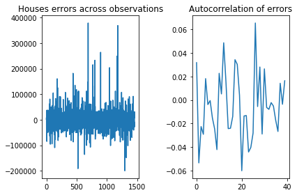

```python
#Condition 5: Error terms uncorrelated with one another.
plt.subplot(1, 2, 1)
plt.plot(errors_houses)
plt.title('Houses errors across observations')

plt.subplot(1, 2, 2)
plt.plot(acf(errors_houses)[1:])
plt.title('Autocorrelation of errors')

plt.tight_layout()
plt.show()
```

Assumption 5 met: Autocorellation is low, ranging from 0.06 to -0.06 (figure 2).

```python
#Assumption 6: Features should not be correlated with errors
houses= pd.concat([houses, errors_houses.rename('errors_houses')], axis=1)
```

```python
houses.corr()[['overallqual', 'garagecars', 'grlivarea', 'totalbsmtsf', 'firstflrsf', 'errors_houses']]
```

[output not shown]

Assumption 6 met: Errors_houses has no correlation with independent variables.